# RDA project

JBNU statistics

2021 12 06

## 목적 : 단동 비닐하우스 환기율 및 온습도에 대한 예측모형 구축 및 평가

## 사용모형 : Multiple Linear Regression Model v.s Artificial Neural Network Model (ANN)

## 1. Loading data (내외부기온차 반응변수)

- 작물있음 데이터에서 외부CO2의 값이 결측치인 경우는 제외하였음.

```r
plantyes <- read.csv("C:/Users/HSY/Desktop/작물있음.csv",sep=",",header=T)
plantyes <- plantyes[is.na(plantyes$외부CO2)==FALSE,]
head(plantyes,10)
```

```
##    외부기온 내부기온 내외부기온차 외부상대습도 내부상대습도 내외부상대습도차
## 1      22.9     31.1          8.3         78.7         55.0             23.7
## 2      22.8     29.7          6.9         77.1         58.7             18.4
## 3      23.3     29.7          6.4         75.5         58.4             17.1
## 4      23.6     29.8          6.2         72.9         57.8             15.1
## 5      24.0     30.0          6.0         71.2         56.4             14.8
## 6      25.1     33.3          8.1         66.6         49.6             17.0
## 7      25.9     35.6          9.7         66.0         43.6             22.4
## 8      25.0     34.0          8.9         68.0         44.9             23.1
## 9      25.9     33.7          7.8         65.6         46.4             19.2
## 10     26.8     35.9          9.1         61.8         44.1             17.7
##    외부CO2 내부CO2 내외부CO2차 외부풍속 외부일사량 환기율 환기창면적 작물유무
## 1    469.5   462.0         7.5    1.398      372.7    5.4       0.15      yes
## 2    464.5   459.7         4.8    1.326      309.9    5.0       0.15      yes
## 3    457.5   451.3         6.2    0.835      291.9    4.0       0.15      yes
```

[output cut: 18 more lines]

```r
plantyes$작물유무 <- as.factor(plantyes$작물유무)
plantno <- read.csv("C:/Users/HSY/Desktop/작물없음.csv",sep=",",header=T)
head(plantno,10)
```

```
##    외부기온 내부기온 내외부기온차 외부상대습도 내부상대습도 내외부상대습도차
## 1      16.8     27.1         10.3         45.1         39.6              5.5
## 2      17.2     28.3         11.1         42.5         37.6              4.9
## 3      17.6     29.1         11.5         42.9         33.2              9.7
## 4      18.0     30.3         12.4         41.2         32.4              8.8
## 5      17.9     30.6         12.7         37.2         28.8              8.4
## 6      18.0     31.3         13.3         37.4         27.1             10.3
## 7      18.0     31.7         13.7         35.8         25.3             10.5
## 8      18.0     32.0         14.0         38.6         24.4             14.2
## 9      18.3     32.7         14.5         37.0         23.5             13.5
## 10     18.3     32.6         14.3         36.1         22.6             13.5
##    외부CO2 내부CO2 내외부CO2차 외부풍속 외부일사량 환기율 환기창면적 작물유무
## 1    543.5   608.0        64.5    1.576      409.4  0.704       0.04       no
## 2    543.0   580.0        37.0    1.707      442.7  0.756       0.04       no
## 3    522.5   585.5        63.0    1.342      476.5  0.634       0.04       no
```

[output cut: 18 more lines]

```r
plantno$작물유무 <- as.factor(plantno$작물유무)
plant <- rbind(plantno,plantyes)
```

## Multiple Linear Regression Model

## 2. 작물유무에 따라 데이터를 나누어서 분석 실시

### 2.1 작물이 없을 때

#### Multiple Linear Regression Model

- 먼저 변수들 간의 상관관계를 파악하기 위해 상관분석을 실시한다.

```r
ex1 <- plantno[,c(3,12,1,10,11,13,14,15)]
head(ex1)
```

```
##   내외부기온차 환기율 외부기온 외부풍속 외부일사량 환기창면적 작물유무
## 1         10.3  0.704     16.8    1.576      409.4       0.04       no
## 2         11.1  0.756     17.2    1.707      442.7       0.04       no
## 3         11.5  0.634     17.6    1.342      476.5       0.04       no
## 4         12.4  0.798     18.0    1.802      505.7       0.04       no
## 5         12.7  1.084     17.9    2.583      536.0       0.04       no
## 6         13.3  1.493     18.0    3.660      564.9       0.04       no
##   작물유무수치
## 1            0
## 2            0
## 3            0
## 4            0
## 5            0
## 6            0
```

```r
ex2 <- ex1[,1:6]
```

```r
cor(ex2)
```

```
##              내외부기온차     환기율      외부기온      외부풍속    외부일사량
## 내외부기온차    1.0000000 -0.6276681  2.541472e-01 -1.836417e-01  6.142775e-01
## 환기율         -0.6276681  1.0000000  1.668245e-01  5.063954e-01  6.080400e-02
## 외부기온        0.2541472  0.1668245  1.000000e+00  3.063871e-01  3.274643e-01
## 외부풍속       -0.1836417  0.5063954  3.063871e-01  1.000000e+00  4.772916e-02
## 외부일사량      0.6142775  0.0608040  3.274643e-01  4.772916e-02  1.000000e+00
## 환기창면적     -0.6558433  0.8309530 -9.044468e-20  3.715441e-20 -5.089237e-20
##                 환기창면적
## 내외부기온차 -6.558433e-01
## 환기율        8.309530e-01
## 외부기온     -9.044468e-20
## 외부풍속      3.715441e-20
## 외부일사량   -5.089237e-20
## 환기창면적    1.000000e+00
```

- 산점도행렬과 상관계수그림을 그리면 다음과 같다.

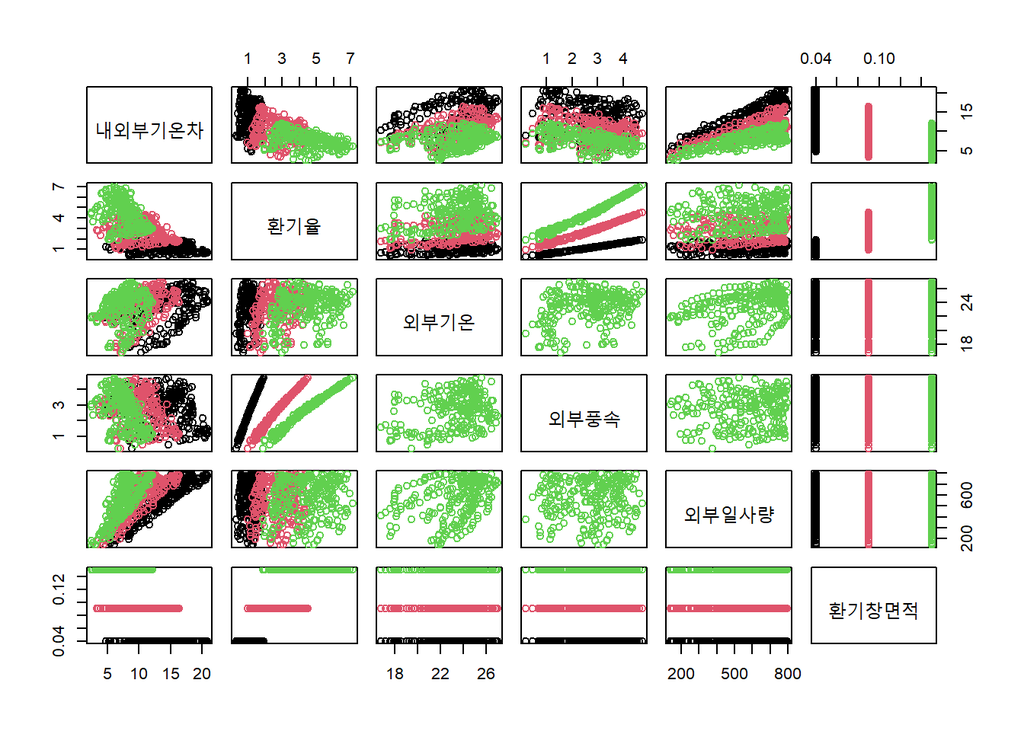

```r
pairs(ex2[1:nrow(plantno),],col=factor(ex2$환기창면적))
```

- 산점도를 통해 알 수 있는 사실은 환기율과 환기창면적이 증가할수록, 외부기온과 외부일사량이 떨어질 수록 내외부기온차가 내려간다는 점이다. 환기창면적과의 교호작용은 뚜렷하게 관측되는 것이 없으나, 외부풍속과의 교호작용의 존재 가능성이 추측된다. 외부풍속은 약하지만 내외부기온차와 음의 상관을 보이는 것으로 생각된다.

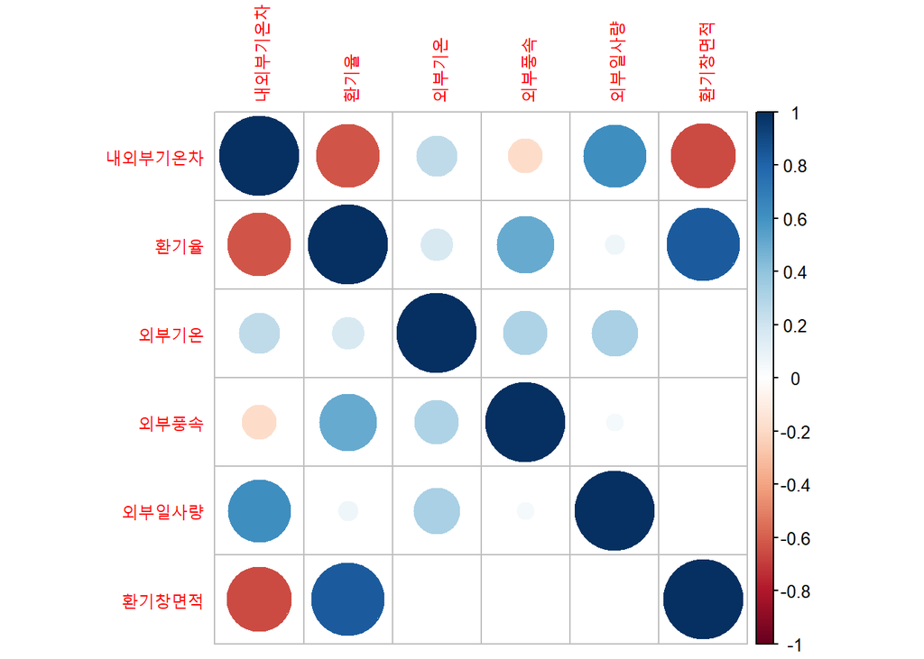

```r
library(corrplot)
corrplot(cor(ex2))
```

- 그리고 각 변수에 대한 기초통계량은 다음과 같이 계산된다.

```r
library(psych)
describe(ex1[,c(-7,-8)])
```

```
##              vars   n   mean     sd median trimmed    mad    min    max  range
## 내외부기온차    1 735  10.60   3.88   9.90   10.35   3.71   2.40  20.90  18.50
## 환기율          2 735   2.81   1.64   2.64    2.68   1.86   0.32   7.09   6.78
## 외부기온        3 735  23.39   2.30  24.00   23.66   1.93  16.80  27.00  10.20
## 외부풍속        4 735   2.71   1.08   2.87    2.73   1.29   0.21   4.74   4.54
## 외부일사량      5 735 568.60 171.31 601.10  584.32 191.40 143.00 795.20 652.20
## 환기창면적      6 735   0.09   0.04   0.09    0.09   0.07   0.04   0.15   0.11
##               skew kurtosis   se
## 내외부기온차  0.54    -0.35 0.14
## 환기율        0.55    -0.67 0.06
## 외부기온     -0.98     0.30 0.08
## 외부풍속     -0.26    -0.99 0.04
## 외부일사량   -0.63    -0.61 6.32
## 환기창면적    0.11    -1.50 0.00
```

- 내외부기온차를 반응변수로 하여 각 변수의 주효과와 환기창면적과의 교호작용을 고려한 다중선형회귀모형을 적합하면 다음과 같다.

```r
m_no <- lm(내외부기온차~환기율+외부기온+외부풍속+외부일사량+환기창면적+환기창면적*환기율+환기창면적*외부기온+환기창면적*외부풍속+환기창면적*외부일사량,data=plantno)
summary(m_no)
```

```
##
## Call:
## lm(formula = 내외부기온차 ~ 환기율 + 외부기온 + 외부풍속 + 외부일사량 +
##     환기창면적 + 환기창면적 * 환기율 + 환기창면적 * 외부기온 +
##     환기창면적 * 외부풍속 + 환기창면적 * 외부일사량, data = plantno)
##
## Residuals:
##     Min      1Q  Median      3Q     Max
## -3.9051 -0.4838  0.0597  0.6174  2.8913
##
## Coefficients:
##                         Estimate Std. Error t value Pr(>|t|)
## (Intercept)           -1.776e+00  8.722e-01  -2.036 0.042080 *
## 환기율                 3.471e+00  3.835e-01   9.051  < 2e-16 ***
## 외부기온               3.831e-01  4.050e-02   9.458  < 2e-16 ***
## 외부풍속              -1.687e-01  9.445e-02  -1.786 0.074561 .
## 외부일사량             2.248e-02  5.186e-04  43.350  < 2e-16 ***
## 환기창면적            -1.293e+01  9.340e+00  -1.385 0.166544
## 환기율:환기창면적      1.688e+01  1.006e+00  16.771  < 2e-16 ***
## 외부기온:환기창면적   -1.509e+00  3.912e-01  -3.858 0.000125 ***
## 외부풍속:환기창면적   -5.231e+01  3.791e+00 -13.798  < 2e-16 ***
## 외부일사량:환기창면적 -1.206e-01  5.443e-03 -22.151  < 2e-16 ***
## ---
## Signif. codes:  0 '***' 0.001 '**' 0.01 '*' 0.05 '.' 0.1 ' ' 1
##
## Residual standard error: 0.9807 on 725 degrees of freedom
## Multiple R-squared:  0.9371, Adjusted R-squared:  0.9363
## F-statistic:  1199 on 9 and 725 DF,  p-value: < 2.2e-16
```

- 모형적합 결과 외부풍속과 환기창면적이 유의수준 0.05에서 유의미하지 않다. 이는 이전 모형에서 환기율이 변수에 의해 거의 완벽하게 설명되기 때문에 환기율을 제외한 다른 변수들을 모형에서 필요로 하지 않는 것으로 생각된다. 즉, 환기율만 모형에 포함시키던지 외부풍속과 환기창면적을 포함시키던지 선택이 필요할 수 있다.
- 그리고 교호작용들 중 외부일사량과 환기창면적 사이의 교호작용에 대한 t 통계량의 절대값이 가장 크므로 이를 가장 중요한 교호작용으로 결정한다.
- 조정된 결정계수의 값이 $R^2_{adj}=0.9363$이다.
- 외부풍속과 환기창면적을 제외한 후 모형을 적합해 보면 다음과 같다. 교호작용은 환기율을 중심으로 형성되도록 하였다.

```r
m_no <- lm(내외부기온차~환기율+외부기온+외부일사량+환기율*외부기온+환기율*외부일사량,data=plantno)
summary(m_no)
```

```
##
## Call:
## lm(formula = 내외부기온차 ~ 환기율 + 외부기온 + 외부일사량 +
##     환기율 * 외부기온 + 환기율 * 외부일사량, data = plantno)
##
## Residuals:
##     Min      1Q  Median      3Q     Max
## -3.8794 -0.9518  0.0965  0.8922  3.1239
##
## Coefficients:
##                     Estimate Std. Error t value Pr(>|t|)
## (Intercept)       -5.3458430  0.9159087  -5.837 8.01e-09 ***
## 환기율             1.1083074  0.3279740   3.379 0.000765 ***
## 외부기온           0.3592877  0.0422421   8.505  < 2e-16 ***
## 외부일사량         0.0213689  0.0005981  35.726  < 2e-16 ***
## 환기율:외부기온   -0.0489423  0.0142761  -3.428 0.000642 ***
## 환기율:외부일사량 -0.0027738  0.0001817 -15.268  < 2e-16 ***
## ---
## Signif. codes:  0 '***' 0.001 '**' 0.01 '*' 0.05 '.' 0.1 ' ' 1
##
## Residual standard error: 1.289 on 729 degrees of freedom
## Multiple R-squared:  0.8906, Adjusted R-squared:  0.8898
## F-statistic:  1187 on 5 and 729 DF,  p-value: < 2.2e-16
```

- 모든 변수가 유의하고 조정된 결정계수의 값이 $R^2_{adj}=0.8898$이다.

#### Best subset selection

- 여러 측도들을 이용하여 모형에 포함될 변수를 적절히 선택해 보도록 하겠다.
- 분석 의뢰기관의 요청에 따라 환기율은 설명변수에서 제외하도록 한다.

```r
library(leaps)
ms0 <- regsubsets(내외부기온차~외부기온+외부풍속+외부일사량+환기창면적+환기창면적*외부기온+환기창면적*외부풍속+환기창면적*외부일사량,data=plantno,
                     nvmax=7)
ms0.summary <- summary(ms0)
ms0.summary
```

```
## Subset selection object
## Call: regsubsets.formula(내외부기온차 ~ 외부기온 + 외부풍속 + 외부일사량 +
##     환기창면적 + 환기창면적 * 외부기온 + 환기창면적 * 외부풍속 +
##     환기창면적 * 외부일사량, data = plantno, nvmax = 7)
## 7 Variables  (and intercept)
##                       Forced in Forced out
## 외부기온                  FALSE      FALSE
## 외부풍속                  FALSE      FALSE
## 외부일사량                FALSE      FALSE
## 환기창면적                FALSE      FALSE
## 외부기온:환기창면적       FALSE      FALSE
## 외부풍속:환기창면적       FALSE      FALSE
## 외부일사량:환기창면적     FALSE      FALSE
## 1 subsets of each size up to 7
## Selection Algorithm: exhaustive
##          외부기온 외부풍속 외부일사량 환기창면적 외부기온:환기창면적
## 1  ( 1 ) " "      " "      " "        "*"        " "
## 2  ( 1 ) " "      " "      "*"        " "        " "
## 3  ( 1 ) " "      "*"      "*"        " "        " "
## 4  ( 1 ) "*"      "*"      "*"        " "        " "
## 5  ( 1 ) "*"      "*"      "*"        " "        " "
## 6  ( 1 ) "*"      "*"      "*"        "*"        "*"
## 7  ( 1 ) "*"      "*"      "*"        "*"        "*"
##          외부풍속:환기창면적 외부일사량:환기창면적
## 1  ( 1 ) " "                 " "
## 2  ( 1 ) " "                 "*"
## 3  ( 1 ) " "                 "*"
## 4  ( 1 ) " "                 "*"
## 5  ( 1 ) "*"                 "*"
## 6  ( 1 ) " "                 "*"
## 7  ( 1 ) "*"                 "*"
```

```r
par(mfrow=c(2,2))
# RSS=SSE
plot(ms0.summary$rss,xlab="Number of Variables",ylab="RSS",type="l")
# Adj R^2
plot(ms0.summary$adjr2,xlab="Number of Variables",ylab="Adjusted RSq",type="l")
which.max(ms0.summary$adjr2)
```

```
## [1] 7
```

```r
points(which.max(ms0.summary$adjr2)
,ms0.summary$adjr2[which.max(ms0.summary$adjr2)
], col="red",cex=2,pch=20)
# Cp
plot(ms0.summary$cp,xlab="Number of Variables",ylab="Cp",type='l')
which.min(ms0.summary$cp)
```

```
## [1] 7
```

```r
points(which.min(ms0.summary$cp)
,ms0.summary$cp[which.min(ms0.summary$cp)
],col="red",cex=2,pch=20)
# BIC
plot(ms0.summary$bic,xlab="Number of Variables",ylab="BIC",type='l')
which.min(ms0.summary$bic)
```

```
## [1] 6
```

```r
points(which.min(ms0.summary$bic)
,ms0.summary$bic[which.min(ms0.summary$bic)
],col="red",cex=2,pch=20)
```

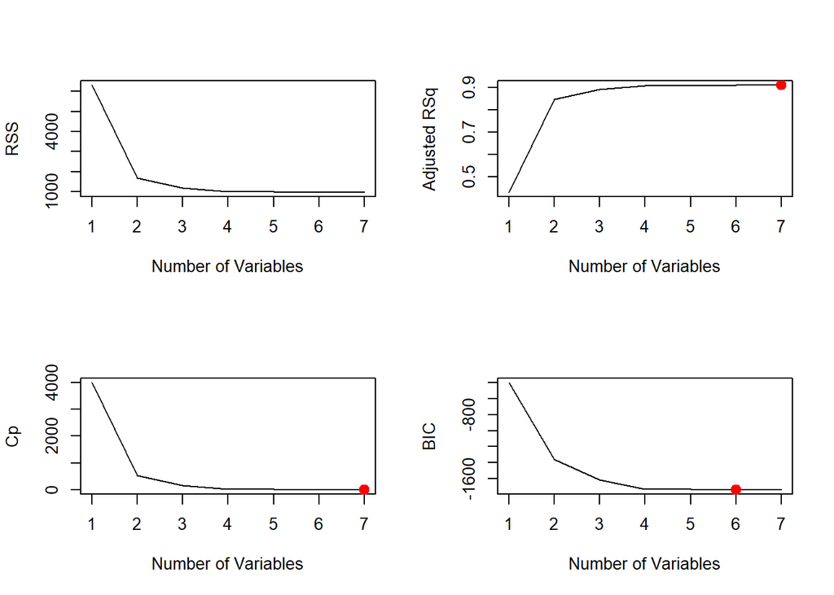

```r
par(mfrow=c(1,1))
```

```r
library(leaps)
ms0 <- regsubsets(내외부기온차~외부기온+외부풍속+외부일사량,data=plantno,
                     nvmax=3)
ms0.summary <- summary(ms0)
ms0.summary
```

```
## Subset selection object
## Call: regsubsets.formula(내외부기온차 ~ 외부기온 + 외부풍속 + 외부일사량,
##     data = plantno, nvmax = 3)
## 3 Variables  (and intercept)
##            Forced in Forced out
## 외부기온       FALSE      FALSE
## 외부풍속       FALSE      FALSE
## 외부일사량     FALSE      FALSE
## 1 subsets of each size up to 3
## Selection Algorithm: exhaustive
##          외부기온 외부풍속 외부일사량
## 1  ( 1 ) " "      " "      "*"
## 2  ( 1 ) " "      "*"      "*"
## 3  ( 1 ) "*"      "*"      "*"
```

```r
par(mfrow=c(2,2))
# RSS=SSE
plot(ms0.summary$rss,xlab="Number of Variables",ylab="RSS",type="l")
# Adj R^2
plot(ms0.summary$adjr2,xlab="Number of Variables",ylab="Adjusted RSq",type="l")
which.max(ms0.summary$adjr2)
```

```
## [1] 3
```

```r
points(which.max(ms0.summary$adjr2)
,ms0.summary$adjr2[which.max(ms0.summary$adjr2)
], col="red",cex=2,pch=20)
# Cp
plot(ms0.summary$cp,xlab="Number of Variables",ylab="Cp",type='l')
which.min(ms0.summary$cp)
```

```
## [1] 3
```

```r
points(which.min(ms0.summary$cp)
,ms0.summary$cp[which.min(ms0.summary$cp)
],col="red",cex=2,pch=20)
# BIC
plot(ms0.summary$bic,xlab="Number of Variables",ylab="BIC",type='l')
which.min(ms0.summary$bic)
```

```
## [1] 3
```

```r
points(which.min(ms0.summary$bic)
,ms0.summary$bic[which.min(ms0.summary$bic)
],col="red",cex=2,pch=20)
```

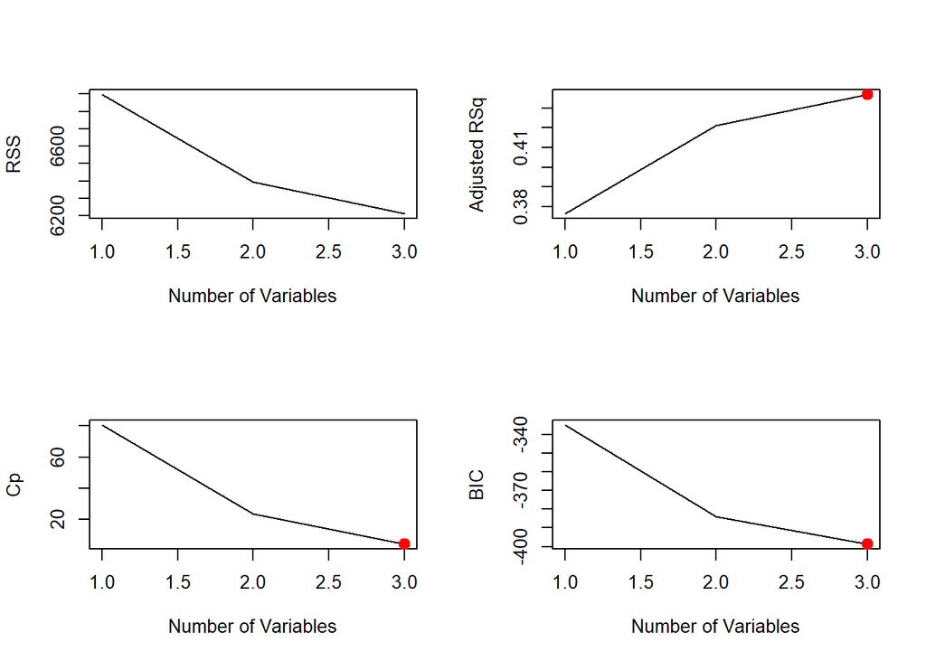

```r
par(mfrow=c(1,1))
```

- 분석결과 3개의 변수를 가지는 모형이 가장 바람직하다고 판단된다.

#### 교차타당검증에 의한 모형 비교

- 지금부터는 train:test=7:3 으로 데이터를 나누어서 몇 개의 후보 모형들의 test RMSE를 계산하여 보겠다. 이 값이 작을수록 예측력이 우수한 모형이라고 볼 수 있다.
- 먼저 데이터를 임의로 train:test=7:3 의 비율로 나눈다. train data는 모형구축 시, test data는 구축된 모형을 평가 시 사용한다.

```r
set.seed(5790)
train.index <- sample(1:nrow(plantno), round(nrow(plantno)*7/10), replace=F)
ex1_train <- plantno[train.index,]
ex1_test <- plantno[-train.index,]
```

```r
# 모든 주효과, 그리고 환기창면적과 다른 변수들 사이의 교호작용을 포함한 모형
m0 <- lm(내외부기온차~환기율+외부기온+외부풍속+외부일사량+환기창면적*환기율+환기창면적+환기창면적*외부기온+환기창면적*외부풍속+환기창면적*외부일사량,data=ex1_train)
y_hat0 <- predict(m0,ex1_test)
RMSE0 <- mean(sum((ex1_test$내부기온-y_hat0)^2))
RMSE0
```

```
## [1] 121251.5
```

```r
# Adj R^2, Cp, BIC 등의 기준을 바탕으로 선택된 모형 (교호작용이 있는 경우는 주효과 포함)
m0 <- lm(내외부기온차~외부기온+외부풍속+외부일사량,data=ex1_train)
y_hat0 <- predict(m0,ex1_test)
RMSE1 <- mean(sum((ex1_test$내부기온-y_hat0)^2))
RMSE1
```

```
## [1] 122339.2
```

```r
# 모든 주효과와 가장 중요한 교호작용 1가지를 포함한 모형 (분석 의뢰기관의 요청에 따라 환기율은 제외)
m0 <- lm(내외부기온차~외부기온+외부풍속+외부일사량+환기창면적+환기창면적*외부일사량,data=ex1_train)
y_hat0 <- predict(m0,ex1_test)
RMSE2 <- mean(sum((ex1_test$내부기온-y_hat0)^2))
RMSE2
```

```
## [1] 121052.2
```

- 결과적으로 3가지 모형들 중 모든 주효과와 가장 중요한 교호작용 1가지를 포함한 모형이 가장 우수하였다.

```r
summary(lm(내부기온~외부기온+외부풍속+외부일사량+환기창면적+환기창면적*외부일사량,data=ex1_train))
```

```
##
## Call:
## lm(formula = 내부기온 ~ 외부기온 + 외부풍속 + 외부일사량 + 환기창면적 +
##     환기창면적 * 외부일사량, data = ex1_train)
##
## Residuals:
##     Min      1Q  Median      3Q     Max
## -3.7715 -0.7266  0.1094  0.8130  3.5462
##
## Coefficients:
##                         Estimate Std. Error t value Pr(>|t|)
## (Intercept)           -0.3970333  0.6513301  -0.610    0.542
## 외부기온               1.2440271  0.0256978  48.410   <2e-16 ***
## 외부풍속              -0.8894703  0.0509490 -17.458   <2e-16 ***
## 외부일사량             0.0228783  0.0007326  31.230   <2e-16 ***
## 환기창면적             2.2893834  4.1722966   0.549    0.583
## 외부일사량:환기창면적 -0.1037146  0.0070312 -14.751   <2e-16 ***
## ---
## Signif. codes:  0 '***' 0.001 '**' 0.01 '*' 0.05 '.' 0.1 ' ' 1
##
## Residual standard error: 1.187 on 508 degrees of freedom
## Multiple R-squared:  0.9429, Adjusted R-squared:  0.9424
## F-statistic:  1678 on 5 and 508 DF,  p-value: < 2.2e-16
```

### 2.2 작물이 있을 때

#### Multiple Linear Regression Model

- 먼저 변수들 간의 상관관계를 파악하기 위해 상관분석을 실시한다.

```r
ex1 <- plantyes[,c(3,12,1,10,11,13,14,15)]
head(ex1)
```

```
##   내외부기온차 환기율 외부기온 외부풍속 외부일사량 환기창면적 작물유무
## 1          8.3    5.4     22.9    1.398      372.7       0.15      yes
## 2          6.9    5.0     22.8    1.326      309.9       0.15      yes
## 3          6.4    4.0     23.3    0.835      291.9       0.15      yes
## 4          6.2    4.2     23.6    0.943      297.5       0.15      yes
## 5          6.0    5.2     24.0    1.481      335.4       0.15      yes
## 6          8.1    4.9     25.1    1.132      549.7       0.15      yes
##   작물유무수치
## 1            1
## 2            1
## 3            1
## 4            1
## 5            1
## 6            1
```

```r
ex2 <- ex1[,1:6]
```

```r
cor(ex2)
```

```
##              내외부기온차      환기율    외부기온    외부풍속  외부일사량
## 내외부기온차    1.0000000 -0.30695945  0.36817225 -0.24325493  0.78030582
## 환기율         -0.3069594  1.00000000  0.04996941  0.76546935  0.10313855
## 외부기온        0.3681722  0.04996941  1.00000000  0.12445561  0.47323743
## 외부풍속       -0.2432549  0.76546935  0.12445561  1.00000000  0.01247939
## 외부일사량      0.7803058  0.10313855  0.47323743  0.01247939  1.00000000
## 환기창면적     -0.4250054  0.67141924 -0.08617862  0.10718424 -0.01979362
##               환기창면적
## 내외부기온차 -0.42500541
## 환기율        0.67141924
## 외부기온     -0.08617862
## 외부풍속      0.10718424
## 외부일사량   -0.01979362
## 환기창면적    1.00000000
```

- 산점도행렬과 상관계수그림을 그리면 다음과 같다.

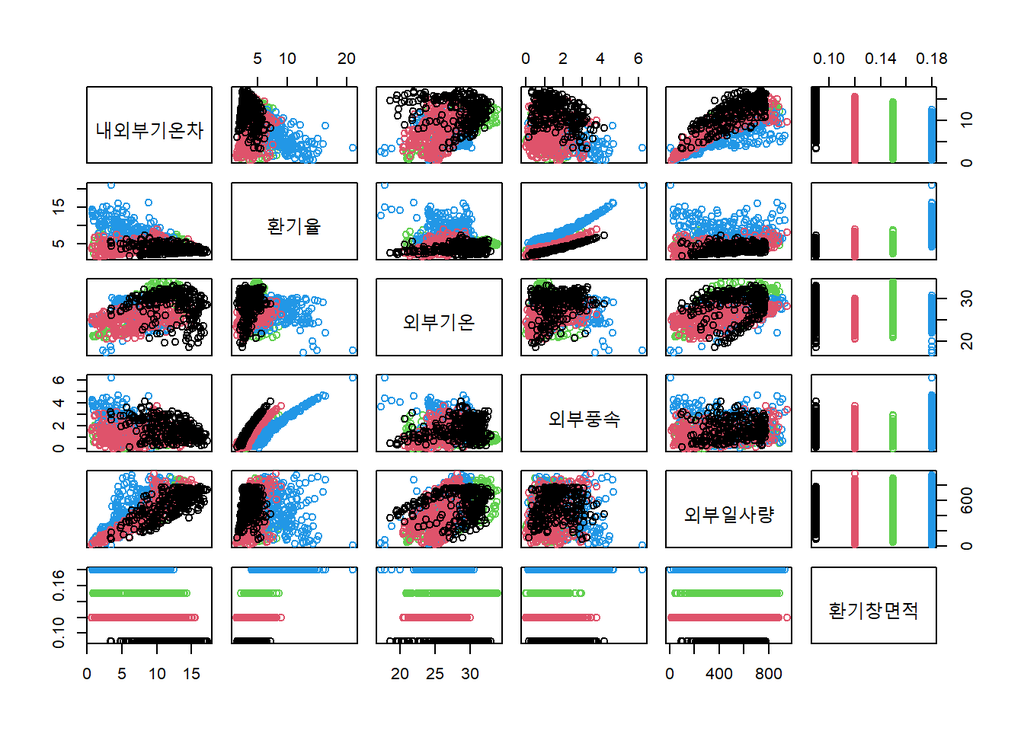

```r
pairs(ex2[1:nrow(plantyes),],col=factor(ex2$환기창면적))
```

- 작물이 없을 때와 유사하다.

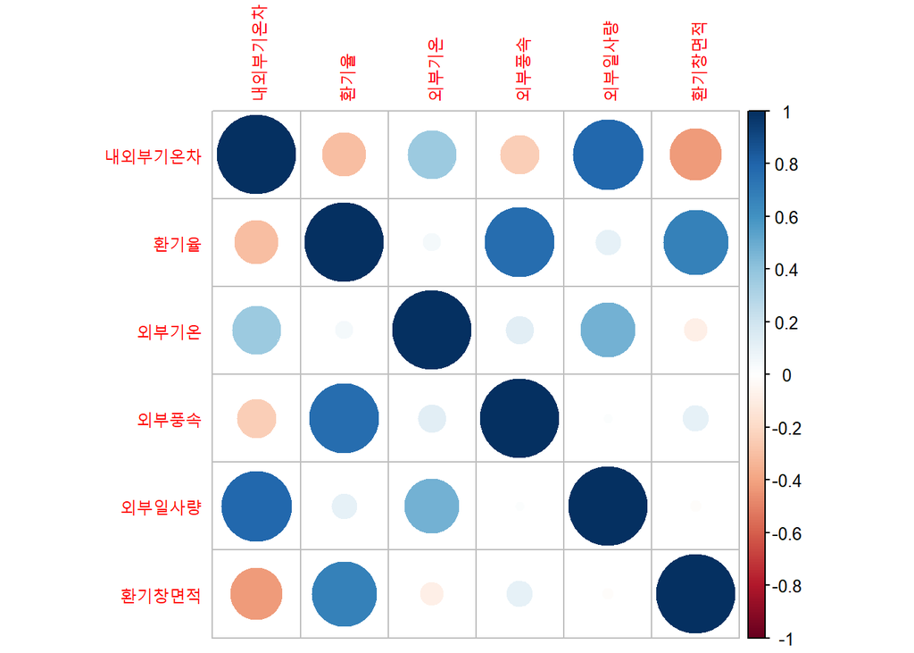

```r
library(corrplot)
corrplot(cor(ex2))
```

- 그리고 각 변수에 대한 기초통계량은 다음과 같이 계산된다. 이 결과에 의하면 5가지 변수들 중 외부일사량이 가장 변동이 크다고 할 수 있다.

```r
library(psych)
describe(ex1[,c(-7,-8)])
```

```
##              vars    n   mean     sd median trimmed    mad   min    max  range
## 내외부기온차    1 1055   8.51   3.86   8.60    8.49   4.30  0.60  17.30  16.70
## 환기율          2 1055   5.15   2.58   4.60    4.77   2.08  1.40  20.90  19.50
## 외부기온        3 1055  26.91   2.99  26.90   26.94   3.26 17.30  33.90  16.60
## 외부풍속        4 1055   1.50   0.92   1.30    1.41   0.83  0.00   6.22   6.21
## 외부일사량      5 1055 459.27 225.19 459.20  460.76 275.02 10.04 950.00 939.96
## 환기창면적      6 1055   0.13   0.03   0.12    0.13   0.04  0.09   0.18   0.09
##               skew kurtosis   se
## 내외부기온차  0.04    -0.78 0.12
## 환기율        1.62     3.44 0.08
## 외부기온     -0.12    -0.42 0.09
## 외부풍속      0.97     0.80 0.03
## 외부일사량   -0.02    -1.02 6.93
## 환기창면적    0.12    -1.38 0.00
```

- 내외부기온차를 반응변수로 하여 각 변수의 주효과와 환기창면적과의 교호작용을 고려한 다중선형회귀모형을 적합하면 다음과 같다.

```r
m_yes <- lm(내외부기온차~환기율+외부기온+외부풍속+외부일사량+환기창면적+환기창면적*환기율+환기창면적*외부기온+환기창면적*외부풍속+환기창면적*외부일사량,data=plantyes)
summary(m_yes)
```

```
##
## Call:
## lm(formula = 내외부기온차 ~ 환기율 + 외부기온 + 외부풍속 + 외부일사량 +
##     환기창면적 + 환기창면적 * 환기율 + 환기창면적 * 외부기온 +
##     환기창면적 * 외부풍속 + 환기창면적 * 외부일사량, data = plantyes)
##
## Residuals:
##     Min      1Q  Median      3Q     Max
## -3.9682 -0.8292  0.0407  0.8939  3.8638
##
## Coefficients:
##                         Estimate Std. Error t value Pr(>|t|)
## (Intercept)            1.387e+01  1.733e+00   8.006 3.13e-15 ***
## 환기율                 1.370e+00  2.297e-01   5.965 3.35e-09 ***
## 외부기온              -2.244e-01  6.155e-02  -3.645  0.00028 ***
## 외부풍속               5.179e-02  3.455e-01   0.150  0.88087
## 외부일사량             2.473e-02  8.310e-04  29.759  < 2e-16 ***
## 환기창면적            -1.065e+02  1.332e+01  -7.994 3.45e-15 ***
## 환기율:환기창면적      5.826e+00  1.205e+00   4.833 1.54e-06 ***
## 외부기온:환기창면적    1.935e+00  4.659e-01   4.154 3.53e-05 ***
## 외부풍속:환기창면적   -3.895e+01  2.763e+00 -14.097  < 2e-16 ***
## 외부일사량:환기창면적 -1.113e-01  6.009e-03 -18.528  < 2e-16 ***
## ---
## Signif. codes:  0 '***' 0.001 '**' 0.01 '*' 0.05 '.' 0.1 ' ' 1
##
## Residual standard error: 1.246 on 1045 degrees of freedom
## Multiple R-squared:  0.8968, Adjusted R-squared:  0.8959
## F-statistic:  1008 on 9 and 1045 DF,  p-value: < 2.2e-16
```

- 모형적합 결과 외부풍속이 유의수준 0.05에서 유의미하지 않았다. 하지만 외부풍속과 환기창면적 사이의 교호작용이 유의하기 때문에 굳이 제외할 필요는 없다고 판단된다. 조정된 결정계수의 값이 $R^2_{adj}=0.8959$이므로 작물이 없을 때와 비교하면 약간 낮은 값이다.
- 그리고 여러 교호작용들 중 t 통계량의 절대값이 가장 큰 외부일사량과 환기창면적 사이의 교호작용을 가장 중요한 교호작용으로 판단할 수 있다.

#### Best subset selection

- 여러 측도들을 이용하여 모형에 포함될 변수를 적절히 선택해 보도록 하겠다.
- 분석 의뢰기관의 요청에 따라 환기율은 제외하고 분석한다.

```r
library(leaps)
ms0 <- regsubsets(내외부기온차~외부기온+외부풍속+외부일사량+환기창면적+환기창면적*외부기온+환기창면적*외부풍속+환기창면적*외부일사량,data=plantyes,
                     nvmax=7)
ms0.summary <- summary(ms0)
ms0.summary
```

```
## Subset selection object
## Call: regsubsets.formula(내외부기온차 ~ 외부기온 + 외부풍속 + 외부일사량 +
##     환기창면적 + 환기창면적 * 외부기온 + 환기창면적 * 외부풍속 +
##     환기창면적 * 외부일사량, data = plantyes, nvmax = 7)
## 7 Variables  (and intercept)
##                       Forced in Forced out
## 외부기온                  FALSE      FALSE
## 외부풍속                  FALSE      FALSE
## 외부일사량                FALSE      FALSE
## 환기창면적                FALSE      FALSE
## 외부기온:환기창면적       FALSE      FALSE
## 외부풍속:환기창면적       FALSE      FALSE
## 외부일사량:환기창면적     FALSE      FALSE
## 1 subsets of each size up to 7
## Selection Algorithm: exhaustive
##          외부기온 외부풍속 외부일사량 환기창면적 외부기온:환기창면적
## 1  ( 1 ) " "      " "      "*"        " "        " "
## 2  ( 1 ) " "      " "      "*"        " "        " "
## 3  ( 1 ) " "      "*"      "*"        " "        " "
## 4  ( 1 ) " "      "*"      "*"        " "        " "
## 5  ( 1 ) " "      "*"      "*"        "*"        " "
## 6  ( 1 ) "*"      "*"      "*"        " "        "*"
## 7  ( 1 ) "*"      "*"      "*"        "*"        "*"
##          외부풍속:환기창면적 외부일사량:환기창면적
## 1  ( 1 ) " "                 " "
## 2  ( 1 ) " "                 "*"
## 3  ( 1 ) " "                 "*"
## 4  ( 1 ) "*"                 "*"
## 5  ( 1 ) "*"                 "*"
## 6  ( 1 ) "*"                 "*"
## 7  ( 1 ) "*"                 "*"
```

```r
par(mfrow=c(2,2))
# RSS=SSE
plot(ms0.summary$rss,xlab="Number of Variables",ylab="RSS",type="l")
# Adj R^2
plot(ms0.summary$adjr2,xlab="Number of Variables",ylab="Adjusted RSq",type="l")
which.max(ms0.summary$adjr2)
```

```
## [1] 7
```

```r
points(which.max(ms0.summary$adjr2)
,ms0.summary$adjr2[which.max(ms0.summary$adjr2)
], col="red",cex=2,pch=20)
# Cp
plot(ms0.summary$cp,xlab="Number of Variables",ylab="Cp",type='l')
which.min(ms0.summary$cp)
```

```
## [1] 4
```

```r
points(which.min(ms0.summary$cp)
,ms0.summary$cp[which.min(ms0.summary$cp)
],col="red",cex=2,pch=20)
# BIC
plot(ms0.summary$bic,xlab="Number of Variables",ylab="BIC",type='l')
which.min(ms0.summary$bic)
```

```
## [1] 3
```

```r
points(which.min(ms0.summary$bic)
,ms0.summary$bic[which.min(ms0.summary$bic)
],col="red",cex=2,pch=20)
```

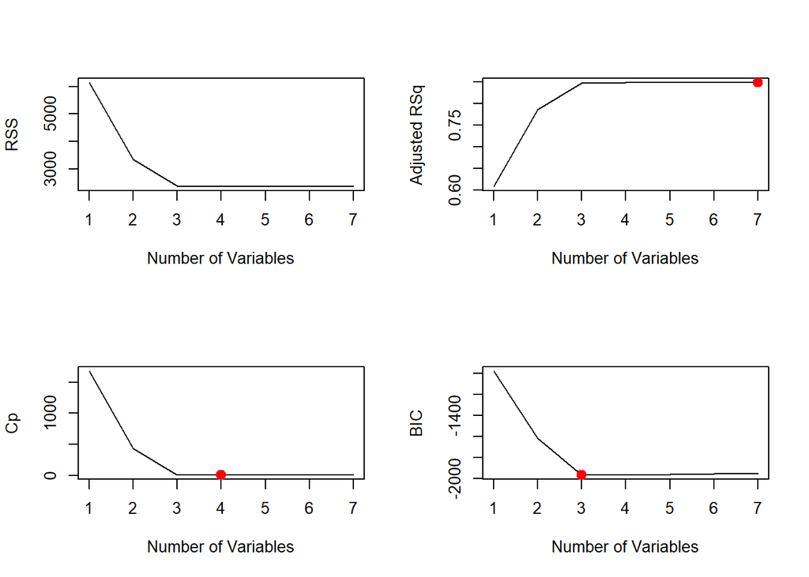

```r
par(mfrow=c(1,1))
```

- 분석결과 $R_{adj}^2$의 경우는 변수의 개수 7인 모형, $Cp$의 경우는 변수의 개수 4인 모형, 그리고 $BIC$의 경우는 변수의 개수 3인 모형을 최적으로 판단하고 있다. 이들 중 가장 단순한 모형인 변수의 개수 3인 모형을 최종적으로 선택하도록 한다. 복잡한 모형이 항상 바람직한 결과를 주지는 않으며 단순한 모형도 설명력이 높은 경우가 많기 때문이다.

#### 교차타당검증에 의한 모형 비교

- 지금부터는 train:test=7:3 으로 데이터를 나누어서 몇 개의 후보 모형들의 test RMSE를 계산하여 보겠다. 이 값이 작을수록 예측력이 우수한 모형이라고 볼 수 있다.
- 먼저 데이터를 임의로 train:test=7:3 의 비율로 나눈다. train data는 모형구축 시, test data는 구축된 모형을 평가 시 사용한다.

```r
set.seed(5790)
train.index <- sample(1:nrow(plantyes), round(nrow(plantyes)*7/10), replace=F)
ex1_train <- plantyes[train.index,]
ex1_test <- plantyes[-train.index,]
```

```r
# 모든 주효과, 그리고 환기창면적과 다른 변수들 사이의 교호작용을 포함한 모형
m0 <- lm(내외부기온차~환기율+외부기온+외부풍속+외부일사량+환기창면적+환기창면적*환기율+환기창면적*외부기온+환기창면적*외부풍속+환기창면적*외부일사량,data=ex1_train)
y_hat0 <- predict(m0,ex1_test)
RMSE0 <- mean(sum((ex1_test$내부기온-y_hat0)^2))
RMSE0
```

```
## [1] 237483.6
```

```r
# Adj R^2, Cp, BIC 등의 기준을 통해 선택된 모형
m0 <- lm(내외부기온차~외부풍속+외부일사량+환기창면적+환기창면적*외부일사량,data=ex1_train)
y_hat0 <- predict(m0,ex1_test)
RMSE1 <- mean(sum((ex1_test$내부기온-y_hat0)^2))
RMSE1
```

```
## [1] 238233.6
```

```r
# 모든 주효과와 가장 중요한 교호작용 1가지를 포함한 모형 (분석 의뢰기관의 요청에 따라 환기율은 제외)
m0 <- lm(내외부기온차~외부기온+외부풍속+외부일사량+환기창면적+환기창면적*외부일사량,data=ex1_train)
y_hat0 <- predict(m0,ex1_test)
RMSE2 <- mean(sum((ex1_test$내부기온-y_hat0)^2))
RMSE2
```

```
## [1] 238166.1
```

- 결과적으로 모든 변수를 포함한 모형이 가장 우수하였다.

```r
summary(lm(내외부기온차~환기율+외부기온+외부풍속+외부일사량+환기창면적+환기창면적*환기율+환기창면적*외부기온+환기창면적*외부풍속+환기창면적*외부일사량,data=ex1_train))
```

```
##
## Call:
## lm(formula = 내외부기온차 ~ 환기율 + 외부기온 + 외부풍속 + 외부일사량 +
##     환기창면적 + 환기창면적 * 환기율 + 환기창면적 * 외부기온 +
##     환기창면적 * 외부풍속 + 환기창면적 * 외부일사량, data = ex1_train)
##
## Residuals:
##     Min      1Q  Median      3Q     Max
## -3.8828 -0.8392  0.0294  0.8986  3.6663
##
## Coefficients:
##                         Estimate Std. Error t value Pr(>|t|)
## (Intercept)            10.767716   2.119273   5.081 4.78e-07 ***
## 환기율                  1.340953   0.283832   4.724 2.77e-06 ***
## 외부기온               -0.091192   0.075964  -1.200   0.2304
## 외부풍속                0.209791   0.421279   0.498   0.6186
## 외부일사량              0.023945   0.001029  23.263  < 2e-16 ***
## 환기창면적            -84.015917  16.237118  -5.174 2.96e-07 ***
## 환기율:환기창면적       6.305672   1.472021   4.284 2.08e-05 ***
## 외부기온:환기창면적     0.966371   0.574434   1.682   0.0929 .
## 외부풍속:환기창면적   -40.727383   3.300731 -12.339  < 2e-16 ***
## 외부일사량:환기창면적  -0.107198   0.007385 -14.515  < 2e-16 ***
## ---
## Signif. codes:  0 '***' 0.001 '**' 0.01 '*' 0.05 '.' 0.1 ' ' 1
##
## Residual standard error: 1.258 on 728 degrees of freedom
## Multiple R-squared:  0.892,  Adjusted R-squared:  0.8907
## F-statistic:   668 on 9 and 728 DF,  p-value: < 2.2e-16
```

### 2.3 작물유무 데이터를 합친 경우

#### Multiple Linear Regression Model

- 상관관계에 대한 분석은 작물유무에 따라 데이터를 나누어 분석하는 과정에서 모두 다루었기 때문에 생략하도록 한다.
- 2.1절과 2.2절의 결과를 통해 환기율과 외부일사량, 그리고 환기창면적과 외부일사량 사이의 교호작용이 유의미하다는 사실을 파악할 수 있다.
- 여기에서는 작물유무에 대한 변수가 추가로 들어가고 이에 따라 작물유무에 대한 교호작용을 포함해서 다양한 교호작용 변수를 고려할 수 있지만 모형이 너무 복잡해지므로 바람직하지 않다. 오히려 중요한 교호작용만을 포함한 모형도 충분한 설명력을 가지기 때문이다.
- 따라서 내외부기온차를 반응변수로 하여 각 변수의 주효과와 환기율과 외부일사량, 그리고 환기창면적과 외부일사량 사이의 교호작용을 포함한 모형을 시작점으로 하여 분석을 진행하도록 한다. 여기에 주효과와 작물유무 사이의 교호작용도 우선 포함한다.

```r
m_total <- lm(내외부기온차~환기율+외부기온+외부풍속+외부일사량+환기창면적+작물유무+환기율*작물유무+외부기온*작물유무+외부풍속*작물유무+외부일사량*작물유무+환기창면적*작물유무+외부일사량*환기율+환기창면적*외부일사량,data=plant)
summary(m_total)
```

```
##
## Call:
## lm(formula = 내외부기온차 ~ 환기율 + 외부기온 + 외부풍속 + 외부일사량 +
##     환기창면적 + 작물유무 + 환기율 * 작물유무 + 외부기온 * 작물유무 +
##     외부풍속 * 작물유무 + 외부일사량 * 작물유무 + 환기창면적 *
##     작물유무 + 외부일사량 * 환기율 + 환기창면적 * 외부일사량,
##     data = plant)
##
## Residuals:
##     Min      1Q  Median      3Q     Max
## -3.8141 -0.8310  0.0269  0.8255  4.3805
##
## Coefficients:
##                          Estimate Std. Error t value Pr(>|t|)
## (Intercept)             3.827e-01  6.072e-01   0.630   0.5286
## 환기율                  4.294e-02  1.312e-01   0.327   0.7435
## 외부기온                2.265e-01  2.270e-02   9.981  < 2e-16 ***
## 외부풍속               -6.209e-01  1.072e-01  -5.790 8.29e-09 ***
## 외부일사량              2.089e-02  5.005e-04  41.733  < 2e-16 ***
## 환기창면적             -1.151e+01  4.822e+00  -2.387   0.0171 *
## 작물유무yes             6.699e+00  7.509e-01   8.922  < 2e-16 ***
## 환기율:작물유무yes      1.096e+00  1.456e-01   7.523 8.43e-14 ***
## 외부기온:작물유무yes   -2.018e-01  2.733e-02  -7.387 2.31e-13 ***
## 외부풍속:작물유무yes   -2.073e+00  1.808e-01 -11.465  < 2e-16 ***
## 외부일사량:작물유무yes  3.453e-03  4.172e-04   8.277 2.45e-16 ***
## 환기창면적:작물유무yes -3.898e+01  5.263e+00  -7.407 1.99e-13 ***
## 환기율:외부일사량      -7.529e-04  7.740e-05  -9.728  < 2e-16 ***
## 외부일사량:환기창면적  -5.860e-02  5.636e-03 -10.397  < 2e-16 ***
## ---
## Signif. codes:  0 '***' 0.001 '**' 0.01 '*' 0.05 '.' 0.1 ' ' 1
##
## Residual standard error: 1.266 on 1776 degrees of freedom
## Multiple R-squared:  0.9007, Adjusted R-squared:  0.8999
## F-statistic:  1239 on 13 and 1776 DF,  p-value: < 2.2e-16
```

- 모형적합 결과 환기율이 유의수준 0.05에서 유의미하지 않다. 하지만 작물유무와의 교호작용은 매우 유의미하기 때문에 제외하지 않는게 더 좋을것 같다고 생각한다.
- 그리고 가장 중요한 교호작용은 두가지를 선택할 수 있는데 바로 t 통계량의 절대값이 가장 큰 작물유무와 외부풍속 사이의 교호작용과 t 통계량의 절대값이 두번째로 큰 외부일사량과 환기창면적 사이의 교호작용이라고 판단된다.
- 조정된 결정계수의 값이 $R^2_{adj}=0.8999$이다.

#### Best subset selection

- 여러 측도들을 이용하여 모형에 포함될 변수를 적절히 선택해 보도록 하겠다.
- 분석 의뢰기관의 요청에 따라 환기율은 분석에서 제외한다.

```r
library(leaps)
ms0 <- regsubsets(내외부기온차~외부기온+외부풍속+외부일사량+환기창면적+작물유무+외부기온*작물유무+외부풍속*작물유무+외부일사량*작물유무+환기창면적*작물유무+환기창면적*외부일사량,data=plant,nvmax=10)
ms0.summary <- summary(ms0)
ms0.summary
```

```
## Subset selection object
## Call: regsubsets.formula(내외부기온차 ~ 외부기온 + 외부풍속 + 외부일사량 +
##     환기창면적 + 작물유무 + 외부기온 * 작물유무 + 외부풍속 *
##     작물유무 + 외부일사량 * 작물유무 + 환기창면적 * 작물유무 +
##     환기창면적 * 외부일사량, data = plant, nvmax = 10)
## 10 Variables  (and intercept)
##                        Forced in Forced out
## 외부기온                   FALSE      FALSE
## 외부풍속                   FALSE      FALSE
## 외부일사량                 FALSE      FALSE
## 환기창면적                 FALSE      FALSE
## 작물유무yes                FALSE      FALSE
## 외부기온:작물유무yes       FALSE      FALSE
## 외부풍속:작물유무yes       FALSE      FALSE
## 외부일사량:작물유무yes     FALSE      FALSE
## 환기창면적:작물유무yes     FALSE      FALSE
## 외부일사량:환기창면적      FALSE      FALSE
## 1 subsets of each size up to 10
## Selection Algorithm: exhaustive
##           외부기온 외부풍속 외부일사량 환기창면적 작물유무yes
## 1  ( 1 )  " "      " "      "*"        " "        " "
## 2  ( 1 )  " "      " "      "*"        " "        " "
## 3  ( 1 )  " "      "*"      "*"        " "        " "
## 4  ( 1 )  " "      "*"      "*"        " "        " "
## 5  ( 1 )  " "      "*"      "*"        " "        " "
## 6  ( 1 )  "*"      "*"      "*"        " "        " "
## 7  ( 1 )  "*"      "*"      "*"        " "        "*"
## 8  ( 1 )  "*"      "*"      "*"        " "        "*"
## 9  ( 1 )  "*"      "*"      "*"        " "        "*"
## 10  ( 1 ) "*"      "*"      "*"        "*"        "*"
##           외부기온:작물유무yes 외부풍속:작물유무yes 외부일사량:작물유무yes
## 1  ( 1 )  " "                  " "                  " "
## 2  ( 1 )  " "                  " "                  " "
## 3  ( 1 )  " "                  " "                  " "
## 4  ( 1 )  " "                  " "                  "*"
## 5  ( 1 )  " "                  "*"                  "*"
## 6  ( 1 )  "*"                  " "                  "*"
## 7  ( 1 )  "*"                  " "                  "*"
## 8  ( 1 )  "*"                  " "                  "*"
## 9  ( 1 )  "*"                  "*"                  "*"
## 10  ( 1 ) "*"                  "*"                  "*"
##           환기창면적:작물유무yes 외부일사량:환기창면적
## 1  ( 1 )  " "                    " "
## 2  ( 1 )  " "                    "*"
## 3  ( 1 )  " "                    "*"
## 4  ( 1 )  " "                    "*"
## 5  ( 1 )  " "                    "*"
## 6  ( 1 )  " "                    "*"
## 7  ( 1 )  " "                    "*"
## 8  ( 1 )  "*"                    "*"
## 9  ( 1 )  "*"                    "*"
## 10  ( 1 ) "*"                    "*"
```

```r
par(mfrow=c(2,2))
# RSS=SSE
plot(ms0.summary$rss,xlab="Number of Variables",ylab="RSS",type="l")
# Adj R^2
plot(ms0.summary$adjr2,xlab="Number of Variables",ylab="Adjusted RSq",type="l")
which.max(ms0.summary$adjr2)
```

```
## [1] 9
```

```r
points(which.max(ms0.summary$adjr2)
,ms0.summary$adjr2[which.max(ms0.summary$adjr2)
], col="red",cex=2,pch=20)
# Cp
plot(ms0.summary$cp,xlab="Number of Variables",ylab="Cp",type='l')
which.min(ms0.summary$cp)
```

```
## [1] 9
```

```r
points(which.min(ms0.summary$cp)
,ms0.summary$cp[which.min(ms0.summary$cp)
],col="red",cex=2,pch=20)
# BIC
plot(ms0.summary$bic,xlab="Number of Variables",ylab="BIC",type='l')
which.min(ms0.summary$bic)
```

```
## [1] 8
```

```r
points(which.min(ms0.summary$bic)
,ms0.summary$bic[which.min(ms0.summary$bic)
],col="red",cex=2,pch=20)
```

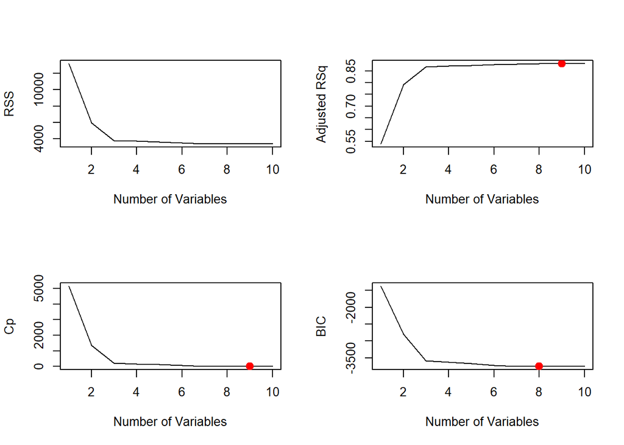

```r
par(mfrow=c(1,1))
```

- 환기창면적을 제외하는 것이 좋다는 결과이다.
- 환기창면적을 제외한 모형에 대해서 다시한번 선택해 보자.

```r
library(leaps)
ms0 <- regsubsets(내외부기온차~외부기온+외부풍속+외부일사량+작물유무+외부기온*작물유무+외부풍속*작물유무+외부일사량*작물유무,data=plant,nvmax=7)
ms0.summary <- summary(ms0)
ms0.summary
```

```
## Subset selection object
## Call: regsubsets.formula(내외부기온차 ~ 외부기온 + 외부풍속 + 외부일사량 +
##     작물유무 + 외부기온 * 작물유무 + 외부풍속 * 작물유무 + 외부일사량 *
##     작물유무, data = plant, nvmax = 7)
## 7 Variables  (and intercept)
##                        Forced in Forced out
## 외부기온                   FALSE      FALSE
## 외부풍속                   FALSE      FALSE
## 외부일사량                 FALSE      FALSE
## 작물유무yes                FALSE      FALSE
## 외부기온:작물유무yes       FALSE      FALSE
## 외부풍속:작물유무yes       FALSE      FALSE
## 외부일사량:작물유무yes     FALSE      FALSE
## 1 subsets of each size up to 7
## Selection Algorithm: exhaustive
##          외부기온 외부풍속 외부일사량 작물유무yes 외부기온:작물유무yes
## 1  ( 1 ) " "      " "      "*"        " "         " "
## 2  ( 1 ) " "      " "      "*"        " "         " "
## 3  ( 1 ) " "      "*"      "*"        "*"         " "
## 4  ( 1 ) "*"      "*"      "*"        " "         "*"
## 5  ( 1 ) "*"      "*"      "*"        "*"         "*"
## 6  ( 1 ) "*"      "*"      "*"        "*"         "*"
## 7  ( 1 ) "*"      "*"      "*"        "*"         "*"
##          외부풍속:작물유무yes 외부일사량:작물유무yes
## 1  ( 1 ) " "                  " "
## 2  ( 1 ) "*"                  " "
## 3  ( 1 ) " "                  " "
## 4  ( 1 ) " "                  " "
## 5  ( 1 ) " "                  " "
## 6  ( 1 ) "*"                  " "
## 7  ( 1 ) "*"                  "*"
```

```r
par(mfrow=c(2,2))
# RSS=SSE
plot(ms0.summary$rss,xlab="Number of Variables",ylab="RSS",type="l")
# Adj R^2
plot(ms0.summary$adjr2,xlab="Number of Variables",ylab="Adjusted RSq",type="l")
which.max(ms0.summary$adjr2)
```

```
## [1] 6
```

```r
points(which.max(ms0.summary$adjr2)
,ms0.summary$adjr2[which.max(ms0.summary$adjr2)
], col="red",cex=2,pch=20)
# Cp
plot(ms0.summary$cp,xlab="Number of Variables",ylab="Cp",type='l')
which.min(ms0.summary$cp)
```

```
## [1] 5
```

```r
points(which.min(ms0.summary$cp)
,ms0.summary$cp[which.min(ms0.summary$cp)
],col="red",cex=2,pch=20)
# BIC
plot(ms0.summary$bic,xlab="Number of Variables",ylab="BIC",type='l')
which.min(ms0.summary$bic)
```

```
## [1] 4
```

```r
points(which.min(ms0.summary$bic)
,ms0.summary$bic[which.min(ms0.summary$bic)
],col="red",cex=2,pch=20)
```

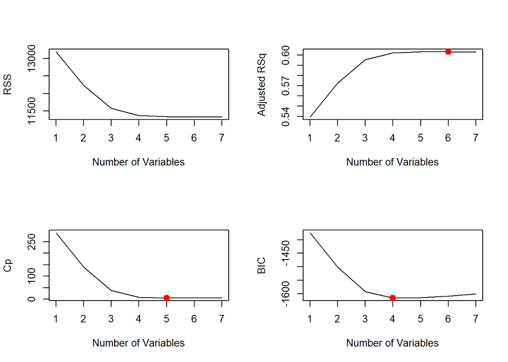

```r
par(mfrow=c(1,1))
```

- 분석결과 $R_{adj}^2$의 경우는 변수의 개수 6인 모형, $Cp$의 경우는 변수의 개수 5인 모형, 그리고 $BIC$의 경우는 변수의 개수 4인 모형을 최적으로 판단하고 있다. 이들 중 가장 단순한 모형인 변수의 개수 4인 모형을 최종적으로 선택하도록 한다. 복잡한 모형이 항상 바람직한 결과를 주지는 않으며 단순한 모형도 설명력이 높은 경우가 많기 때문이다.

```r
summary(lm(내외부기온차~외부기온+외부풍속+외부일사량+작물유무+외부기온*작물유무,data=plant))
```

```
##
## Call:
## lm(formula = 내외부기온차 ~ 외부기온 + 외부풍속 + 외부일사량 +
##     작물유무 + 외부기온 * 작물유무, data = plant)
##
## Residuals:
##     Min      1Q  Median      3Q     Max
## -7.0137 -1.6410 -0.3841  1.6643  6.7903
##
## Coefficients:
##                        Estimate Std. Error t value Pr(>|t|)
## (Intercept)          -0.0766659  0.9535768  -0.080    0.936
## 외부기온              0.2535895  0.0423565   5.987 2.58e-09 ***
## 외부풍속             -1.0063202  0.0622361 -16.169  < 2e-16 ***
## 외부일사량            0.0131335  0.0003241  40.523  < 2e-16 ***
## 작물유무yes           2.8354435  1.1969785   2.369    0.018 *
## 외부기온:작물유무yes -0.2078412  0.0487141  -4.267 2.09e-05 ***
## ---
## Signif. codes:  0 '***' 0.001 '**' 0.01 '*' 0.05 '.' 0.1 ' ' 1
##
## Residual standard error: 2.521 on 1784 degrees of freedom
## Multiple R-squared:  0.6042, Adjusted R-squared:  0.6031
## F-statistic: 544.7 on 5 and 1784 DF,  p-value: < 2.2e-16
```

#### 교차타당검증에 의한 모형 비교

- 지금부터는 train:test=7:3 으로 데이터를 나누어서 몇 개의 후보 모형들의 test RMSE를 계산하여 보겠다. 이 값이 작을수록 예측력이 우수한 모형이라고 볼 수 있다.
- 먼저 데이터를 임의로 train:test=7:3 의 비율로 나눈다. train data는 모형구축 시, test data는 구축된 모형을 평가 시 사용한다.

```r
set.seed(5790)
train.index <- sample(1:nrow(plant), round(nrow(plant)*7/10), replace=F)
ex1_train <- plant[train.index,]
ex1_test <- plant[-train.index,]
```

```r
# 최초로 고려한 모형
m0 <- lm(내외부기온차~환기율+외부기온+외부풍속+외부일사량+환기창면적+작물유무+환기율*작물유무+외부기온*작물유무+외부풍속*작물유무+외부일사량*작물유무+환기창면적*작물유무+외부일사량*환기율+환기창면적*외부일사량,data=ex1_train)
y_hat0 <- predict(m0,ex1_test)
RMSE0 <- mean(sum((ex1_test$내부기온-y_hat0)^2))
RMSE0
```

```
## [1] 359467
```

```r
# Adj R^2, Cp, BIC 등의 기준을 바탕으로 선택된 모형 (교호작용이 있는 경우는 주효과 포함)
m0 <- lm(내외부기온차~외부기온+외부풍속+외부일사량+작물유무+외부기온*작물유무,data=plant)
y_hat0 <- predict(m0,ex1_test)
RMSE1 <- mean(sum((ex1_test$내부기온-y_hat0)^2))
RMSE1
```

```
## [1] 360042.7
```

```r
# 모든 주효과와 가장 중요한 교호작용 2가지를 포함한 모형
# 분석 의뢰기관의 요청에 따라 환기율은 제외
m0 <- lm(내외부기온차~외부기온+외부풍속+외부일사량+환기창면적+작물유무+외부풍속*작물유무+환기창면적*외부일사량,data=ex1_train)
y_hat0 <- predict(m0,ex1_test)
RMSE2 <- mean(sum((ex1_test$내부기온-y_hat0)^2))
RMSE2
```

```
## [1] 358761.3
```

- 결과적으로 3가지 모형들 중 모든 주효과와 가장 중요한 교호작용 2가지를 포함한 모형이 가장 우수하였다.

```r
summary(lm(내외부기온차~외부기온+외부풍속+외부일사량+환기창면적+작물유무+외부풍속*작물유무+환기창면적*외부일사량,data=ex1_train))
```

```
##
## Call:
## lm(formula = 내외부기온차 ~ 외부기온 + 외부풍속 + 외부일사량 +
##     환기창면적 + 작물유무 + 외부풍속 * 작물유무 + 환기창면적 *
##     외부일사량, data = ex1_train)
##
## Residuals:
##     Min      1Q  Median      3Q     Max
## -4.5993 -0.9264  0.1242  0.9196  6.2496
##
## Coefficients:
##                         Estimate Std. Error t value Pr(>|t|)
## (Intercept)            2.6586213  0.5127509   5.185 2.52e-07 ***
## 외부기온               0.0787033  0.0165747   4.748 2.29e-06 ***
## 외부풍속              -0.7931335  0.0595252 -13.324  < 2e-16 ***
## 외부일사량             0.0231799  0.0006316  36.698  < 2e-16 ***
## 환기창면적            -6.3609372  2.7911817  -2.279   0.0228 *
## 작물유무yes            0.3932798  0.2206872   1.782   0.0750 .
## 외부풍속:작물유무yes  -0.1950758  0.0814793  -2.394   0.0168 *
## 외부일사량:환기창면적 -0.0810777  0.0048196 -16.823  < 2e-16 ***
## ---
## Signif. codes:  0 '***' 0.001 '**' 0.01 '*' 0.05 '.' 0.1 ' ' 1
##
## Residual standard error: 1.43 on 1245 degrees of freedom
## Multiple R-squared:  0.8733, Adjusted R-squared:  0.8726
## F-statistic:  1225 on 7 and 1245 DF,  p-value: < 2.2e-16
```